# Reproducible Research: Peer Assessment 1

## Loading and preprocessing the data

```r
library(dplyr)
library(lubridate)
library(ggplot2)
library(knitr)
opts_chunk$set(fig.path='figure/')
Sys.setlocale("LC_TIME", "en_US.UTF8")
```

```
## [1] "en_US.UTF8"
```

1. Load the data

```r
# unzip and read activity data
zipfile <- "activity.zip"
csvfile <- "activity.csv"
activity <- read.csv(unz(zipfile,csvfile), sep = ",")
```

2. Process/transform the data into a format suitable

```r
activity <- na.omit(activity)
activity$interval <- ((activity$interval%/% 100 * 60) + activity$interval%%100)*60
```

## What is mean total number of steps taken per day?

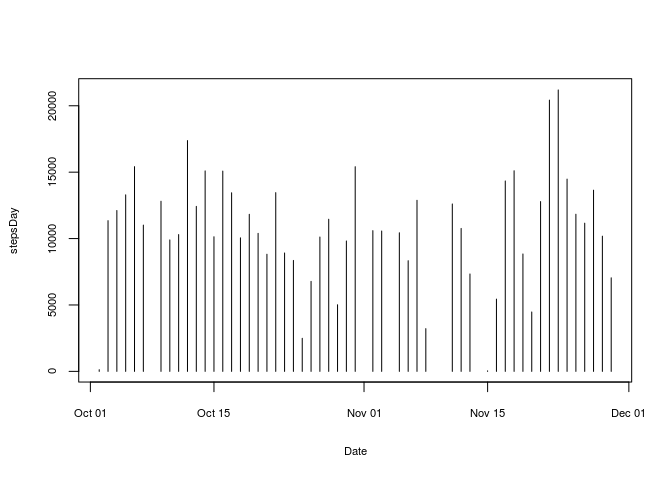

```r
activity_df <- tbl_df(activity)
activity.dailySteps <- activity_df %>%
      group_by(date) %>%
      summarise(stepsDay = sum(steps))
with(activity.dailySteps,plot(as.Date(date,'%Y-%m-%d'),stepsDay,
                type = "h",
                cex.lab=0.7,
                cex.axis=0.7,
                cex.main=0.7,
                cex.sub=0.7,
                xlab="Date"))
```

2. The mean and median total number of steps taken per day

```r
summary(activity.dailySteps$stepsDay)
```

```
##    Min. 1st Qu.  Median    Mean 3rd Qu.    Max.
##      41    8841   10760   10770   13290   21190
```

## What is the average daily activity pattern?

1. Time series plot of the 5-minute interval (x-axis) and the average number of steps taken, averaged across all days (y-axis)

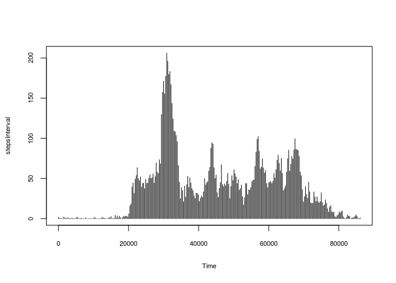

```r
activity_df <- tbl_df(activity)
activity.stepsInterval <- activity_df %>%
      group_by(interval) %>%
      summarise(stepsInterval = mean(steps))

with(activity.stepsInterval,plot(interval,stepsInterval,
                              type = "h",
                              cex.lab=0.7,
                              cex.axis=0.7,
                              cex.main=0.7,
                              cex.sub=0.7,
                              xlab="Time"))
```

2. Which 5-minute interval, on average across all the days in the dataset, contains the maximum number of steps?

```r
seconds_to_period(activity.stepsInterval$interval[which.max(activity.stepsInterval$stepsInterval)])
```

```
## [1] "8H 35M 0S"
```

## Imputing missing values

1. The total number of missing values in the dataset

```r
activity_na <- read.csv(unz(zipfile,csvfile), sep = ",")
sum(is.na(activity_na))
```

```
## [1] 2304
```

2. Strategy for filling in all of the missing values in the dataset: Fill with the mean of that interval

```r
activity_na$steps[is.na(activity_na$steps)] <- activity.stepsInterval$stepsInterval
```

3. Create a new dataset that is equal to the original dataset but with the missing data filled in.

```r
activity_filled <-activity_na
head(activity_filled)
```

```
##       steps       date interval
## 1 1.7169811 2012-10-01        0
## 2 0.3396226 2012-10-01        5
## 3 0.1320755 2012-10-01       10
## 4 0.1509434 2012-10-01       15
## 5 0.0754717 2012-10-01       20
## 6 2.0943396 2012-10-01       25
```

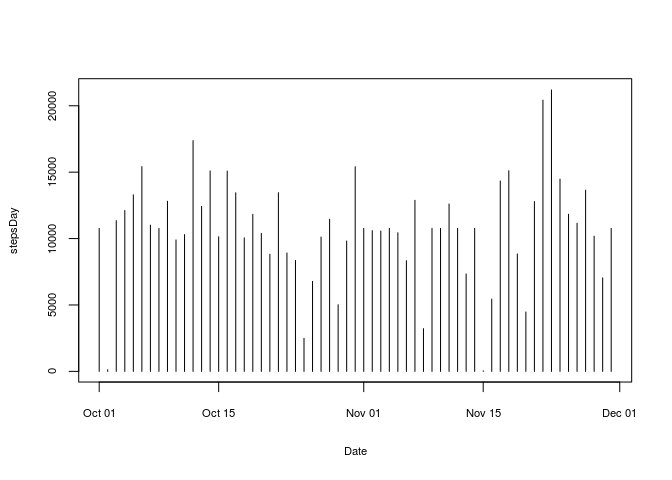

```r
activity_filled_df <- tbl_df(activity_filled)
activity_filled.dailySteps <- activity_filled_df %>%
      group_by(date) %>%
      summarise(stepsDay = sum(steps))

with(activity_filled.dailySteps,plot(as.Date(date,'%Y-%m-%d'),stepsDay,
                              type = "h",
                              cex.lab=0.7,
                              cex.axis=0.7,
                              cex.main=0.7,
                              cex.sub=0.7,
                              xlab="Date"))
```

```r
summary(activity_filled.dailySteps$stepsDay)
```

```
##    Min. 1st Qu.  Median    Mean 3rd Qu.    Max.
##      41    9819   10770   10770   12810   21190
```

The mean didn’t differ because of the fill startegy but median does a little bit. There is almost no impact of imputing missing data.

## Are there differences in activity patterns between weekdays and weekends?

1. Create a new factor variable in the dataset with two levels – “weekday” and “weekend” indicating whether a given date is a weekday or weekend day.

```r
activity_filled$day[weekdays(as.Date(activity_filled$date)) %in% c('Saturday','Sunday')] <- 'weekend'
activity_filled$day[is.na(activity_filled$day)] <- 'weekday'
```

2. A panel plot containing a time series plot of the 5-minute interval (x-axis) and the average number of steps taken, averaged across all weekday days or weekend days (y-axis).

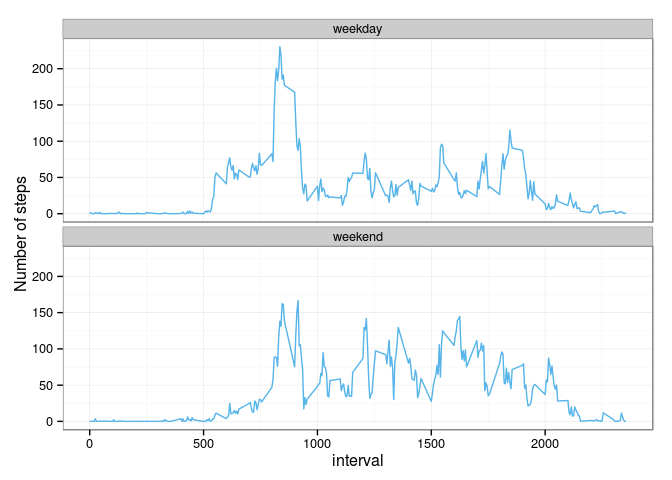

```r
activity_df <- tbl_df(activity_filled)
activity_filled.stepsInterval <- activity_df %>%
      group_by(day,interval) %>%
      summarise(stepsInterval = mean(steps))

g <- ggplot(activity_filled.stepsInterval,aes(x=interval,y=stepsInterval))
g + geom_line(colour="#56B4E9") +  facet_wrap(~ day, nrow = 2, ncol = 1,) + labs(y = "Number of steps") + theme_bw()
```